# STAT 331 Portfolio

## Program Efficiency

**PE-1: I can write concise code which does not repeat itself.**

- using a single function call with multiple inputs (rather than multiple function calls)

```r
#Lab 4, Question 4
ca_childcare <- ca_childcare |>
  mutate(
    county_name = str_remove(county_name, " County"),
    region = fct_collapse(
      county_name,
    "Superior California" = superior_counties,
    "North Coast" = north_coast_counties,
    "San Francisco Bay Area" = san_fran_counties,
    "Northern San Joaquin Valley" = n_san_joaquin_counties,
    "Central Coast" = central_coast_counties,
    "Southern San Joaquin Valley" = s_san_joaquin_counties,
    "Central Coast" = central_coast_counties,
    "Southern San Joaquin Valley" = s_san_joaquin_counties,
    "Inland Empire" = inland_counties,
    "Los Angeles" = la_county,
    "Orange" = orange_county,
    "San Diego-Imperial" = san_diego_imperial_counties
  ))
    count(ca_childcare, region)

#Reflection: Instead of calling the mutate() function twice, I made my code more efficient so that it's only called once.
```

- using `across()`

```r
#Lab 8, Question 1
rescale_column <- function(df, cols) {
  if (!is.data.frame(df)) {
    stop("Error: Input must be a data frame.")
  }
  df |>
    mutate(across({{ cols }}, ~ rescale_01(.x)))
}
```

- using functions from the `map()` family

```r
#Lab 10, Question 1
#| label: pe-1-map-1
results <- map_int(.x = 1:10000,
                   .f = ~ randomBabies(4)
                  )
table(results)
```

**PE-2: I can write functions to reduce repetition in my code.**

- Example 1: Function that operates on vectors

```r
#Lab 7, Question 4
#| label: pe-2-1
rescale_01 <- function(x) {
  if(!is.numeric(x)) {
    stop("Error: Input vector must be a numeric value")
}

  if (length(x) <= 1) {
    stop("Error: Input vector must have more than one value
    ")
}
  rng <-range(x, na.rm = TRUE)
  (x - rng[1]) / (rng[2] - rng[1])
}
```

- Example 2: Function that operates on data frames

```r
#Lab 8, Question 1
#| label: pe-2-2
rescale_column <- function(df, cols) {

  if (!is.data.frame(df)) {
    stop("Error: Input must be a data frame.")
  }
  df |>
    mutate(across({{ cols }}, ~ rescale_01(.x)))
}
```

- Example 3: Function that operates on vectors *or* data frames

```r
#Lab 8, Question 2
#| label: pe-2-3
pivot_table <- function(df, row_var, col_var) {
  df |>
    count({{ row_var }}, {{ col_var }}) |>
    pivot_wider(
      names_from = {{ col_var }},
      values_from = n,
      values_fill = 0
    ) |>
    janitor::adorn_totals(where = c("row", "col"))
}
```

**PE-3:I can use iteration to reduce repetition in my code.**

- using `across()`

```r
#Lab 7, Question 1
missing_summary <- fish |>
  summarise(num_missing_obs = sum(if_any(everything(), is.na)),
            across(everything(), ~ sum(is.na(.))))
```

- using a `map()` function with **one** input (e.g., `map()`, `map_chr()`, `map_dbl()`, etc.)

```r
#Lab 9, Question 3
types_tbl <- map_chr(surveys, typeof) |>
  enframe(name = "Variable", value = "Data_Type") |>
  arrange(Data_Type) |>
  kable(
    caption = "**Data Types of Variables in the Survey Dataset**",
    col.names = c("Variable", "Data Type"))
```

```r
#Lab 9, Question 7
map_int(fish, ~ sum(is.na(.x))) |>
  enframe(name = "Variable", value = "Missing Values") |>
  gt() |>
  tab_header(
    title = "Missing Values per Variable",
    subtitle = "Blackfoot Fish Dataset"
  ) |>
  cols_label(
    Variable = "Variable",
    `Missing Values` = "Missing Values"
  ) |>
  tab_options(
    table.font.size = 14
  )
```

**PE-4: I can use modern tools when carrying out my analysis.**

- I can use functions which are not superseded or deprecated

```r
#Lab 4, Question 7
accent10 <- colorRampPalette(brewer.pal(7, "Accent")) (10)

ca_childcare_long <- ca_childcare |>
  select(region, study_year, mc_infant, mc_toddler, mc_preschool) |>
  pivot_longer(
    cols = starts_with("mc_"),
    names_to = "age_group",
    values_to = "weekly_price"
  ) |>
  mutate(
    age_group = case_match(age_group,
                       "mc_infant" ~ "Infant",
                       "mc_toddler" ~ "Toddler",
                       "mc_preschool" ~ "Preschool"),
    age_group = factor(age_group, levels = c("Infant", "Toddler", "Preschool")),
    region = fct_reorder2(region, study_year, weekly_price)
  )
```

- I can connect a data wrangling pipeline into a `ggplot()`

```r
#Edited code from Challenge 4 to remove ca_afford_long by piping dplyr into ggplot
ca_afford |>
  select(study_year, center_afford, family_afford) |>
  pivot_longer(
    cols = c(center_afford, family_afford),
    names_to = "Setting",
    values_to = "Affordability"
  ) |>
  mutate(
    Setting = recode(
      Setting,
      center_afford = "Center-Based",
      family_afford = "Family-Based"
    )
  ) |>
  ggplot(aes(x = study_year, y = Affordability, color = Setting)) +
  stat_summary(fun = median, geom = "line", linewidth = 1.2) +
  stat_summary(fun = median, geom = "point", size = 2.2) +
  scale_y_continuous(labels = scales::label_percent(accuracy = 1)) +
  labs(
    title = "Affordability of Childcare in California (2008–2018)",
    subtitle = "Median Weekly Cost as a Share of County Median Household Income",
    x = "Year",
    y = "Median Share of Weekly Income Spent on Infant Care",
    color = "Childcare Setting"
  ) +
  theme_minimal(base_size = 11) +
  theme(
    plot.title = element_text(face = "bold", size = 15, hjust = 0.5),
    plot.subtitle = element_text(size = 12, hjust = 0.5),
    legend.position = "top"
  )
```

## Data Simulation & Statistical Models

**DSSM-1: I can simulate data from a *variety* of probability models.**

- Example 1

```r
#Lab 10, Question 1
#Simulating from a Discrete Uniform Distribution
randomBabies <- function(n_babies){
  assigned <- sample(1:n_babies, size = n_babies, replace = FALSE)
  sum(assigned == 1:n_babies)
}

results <- map_int(.x = 1:10000,
                   .f = ~ randomBabies(4)
                  )
table(results)
```

- Example 2

```r
#Lab 10, Question 4
#Simulates from a Uniform and Normal distribution

#define slope and intercept parameters
intercept = 2
slope = 1

# generate x vector
x <- runif(100, min = 0, max = 1)

# generate noise `ep` vector
ep <- rnorm(100, mean = 0, sd = 1)

# generate outcome from population model
y = intercept + x*slope + ep


# create an "observed data" data frame with only the x and y vectors
observed_data <- tibble(
  x = x,
  y = y
)
```

**DSSM-2: I can conduct common statistical analyses in R.**

- Example 1

```r
#Lab 4, Question 8
#Showcasing Linear Regression
reg_mod1 <- lm(mc_infant ~ mhi_2018, data = ca_childcare)
summary(reg_mod1)
```

- Example 2

```r
#Challenge 3, Question 3
#Showcasing Chi-Square Test of Indepedence, edited to remove table
chisq.test(teacher_evals_compare$SET_level, teacher_evals_compare$sen_level)
```

- Example 3

```r
#Lab 1, Question 9
#Showcasing Two-Sided T-test
t.test(len ~ supp, data = ToothGrowth, var.equal = FALSE, alternative = "two.sided")
```

## Revising My Thinking

Throughout this Computing with R course, I would say my understanding of coding and problem-solving has only evolved. Towards the start of the course, working in R, which I had slight experience in from previous stat classes, to now being fully fledged in Quarto was a definitely a little bit of an adjustment to get used the different formatting styles and overall environment. The first few labs/practice activities I was mainly focused on even getting code to run without int erupting errors that would display something relatively close to what I was aiming for. Upon reading feedback, like my use of superseded functions, non-tidy code, formatting issues, etc. I really tried to put a lot of conscious time and effort into improving those aspects of my R code by learning from and processing the feedback I received. Doing this portfolio really made me think about the intricate details that coding involves and how it all sort of builds on each other, assignment after assignment, to overall complement different functions/programs together. Being aware and thoughtful about my responses for this portfolio also allowed me to revise some prior code to include another aspect I wanted to include or even catch and fix up smaller errors.

## Extending My Thinking

I would say that as the quarter goes on, I really began to think about coding and programming as a whole as not just following instructions off of a lab or practice activity, but instead thinking about the overall usage of each new skill/package learned and how they all logically interact. I believe I extended my thinking by experimenting with unique ideas, formats and being an active learner in class who utilize support from classmates/instructors. This whole class and it’s content have been completely new to me so I think every opportunity I get to learn something new and add another package to my coding arsenal is a way I extend my thinking and knowledge as a hopeful data scientist.

## Peer Support & Collaboration

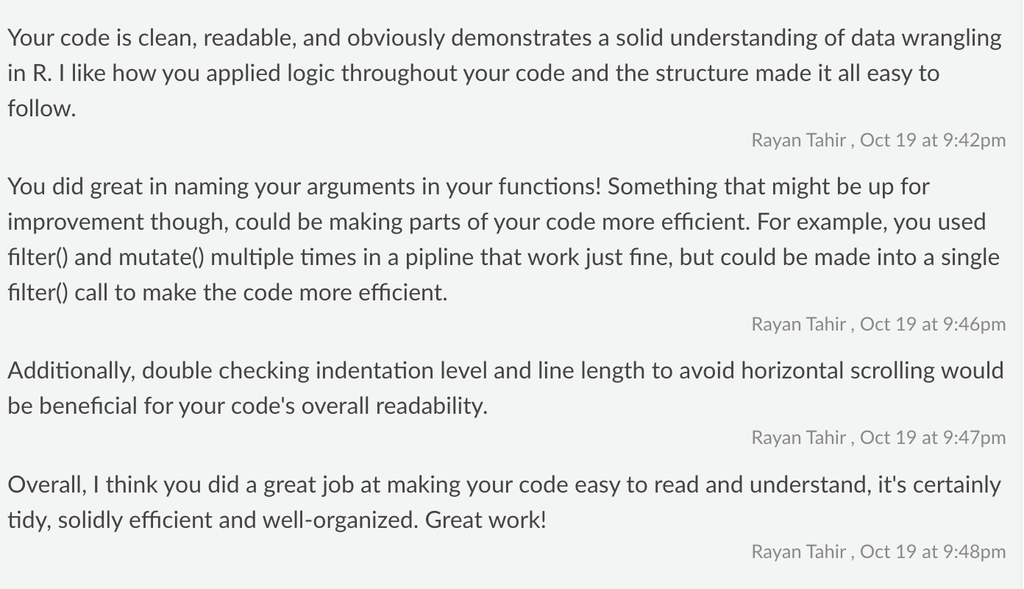

This a screenshot of the comments I provided for the Lab 4, Peer Review. I feel like my feedback was actionable and thoughtful, while still giving the coder their props on an overall good code execution.

Throughout our weekly pair programming, I would definitely say I grew a lot as a collaborator and coder. The first few practice activities took some getting used to, with new faces in your class that you’ve never met before, and working to utilize the “Coder and Typer” switch-off positions in the correct way. I think over time, I really learned some effective ways to communicate and help within both roles. With coding, especially in partner work, patience is certainly a virtue as not everything will work out the exact way you want it the first time but if you stay calm and keep collaboration high everything always ends up solved by the end.